# Insights and Visualizations of WeRateDogs Twitter Archive

## Visualizing the ten most predicted breeds of dogs

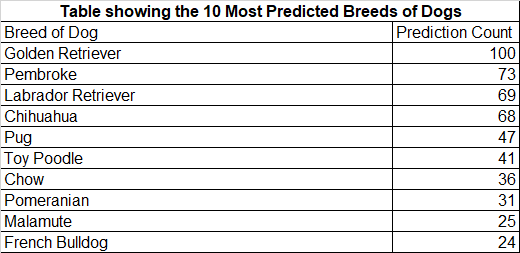

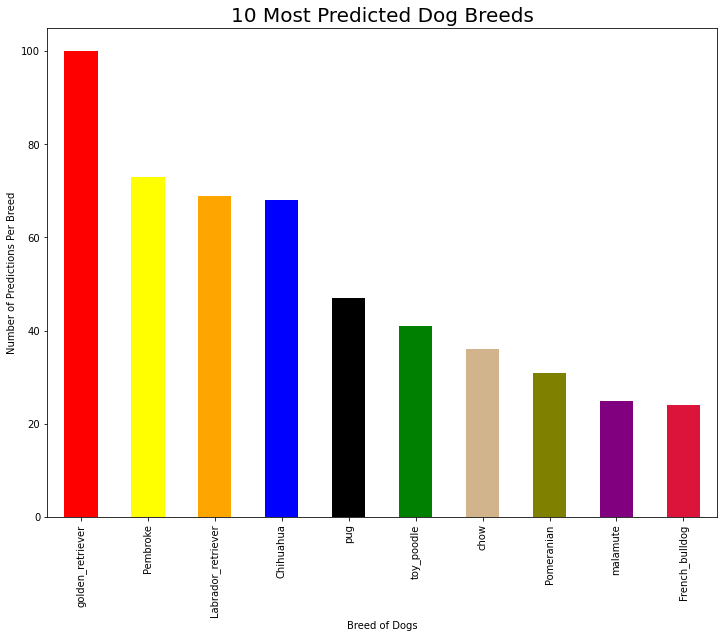

The WeRateDogs Twitter Archive shows that the golden retriever is the most predicted breed with a prediction count of 100. This goes to show that from the text reviews, there is a possibility that most of the people who twitted either owned, or have had experience with a golden retriever. For people who would want to market commodities on the page of the WeRateDog twitter account, they would make more sale if the product matched the requirements of a golden retriever.

## Relationship between the number of likes and numbver of retweets in the WeRateDogs Twitter Archive

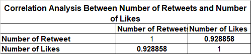

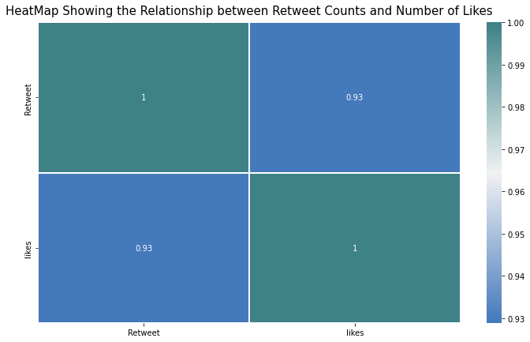

The value of 0.92 shows a 92% correlation between the number of retweets and the number of likes. This is a very high correlation. Usually, any correlation that is greater than 60% is considered high. Apart from the magnitude of this realtionship (high correlation), the sign shows a positive relationship between the two variables (i.e., the number of retweets and the number of likes).

However, it is very important to note that this does not show the direction of the relationship. This means that we cannot categorically state which of these factors is influencing the other. So in order to undrstand the direction of the relationship, a regression analysis would be ideal. But we did not conduct a regression analysis between these two variables, rather we examined the effect of both variables on the confidence of prediction (to be discussed in details later!). The heatmap presents a visualization of this correlation.

## Distribution of Dog Stages by The Number of Retweets

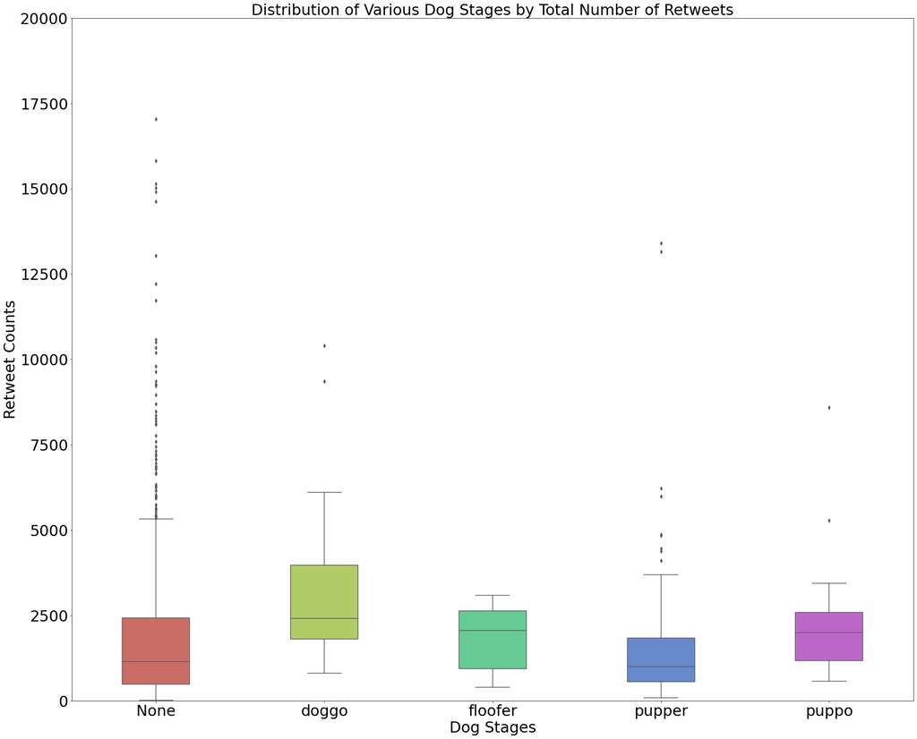

There were lots of outliers among the dogs not classified into any stage ("None"). However, the mean of number of retweets for "doggo" stage is the highest compared to other stages. This was followed by the "puppo" stahe. "Puppa" stage had the lowest mean value for retweets.

## Distribution of Dog Stages by the Number of Likes

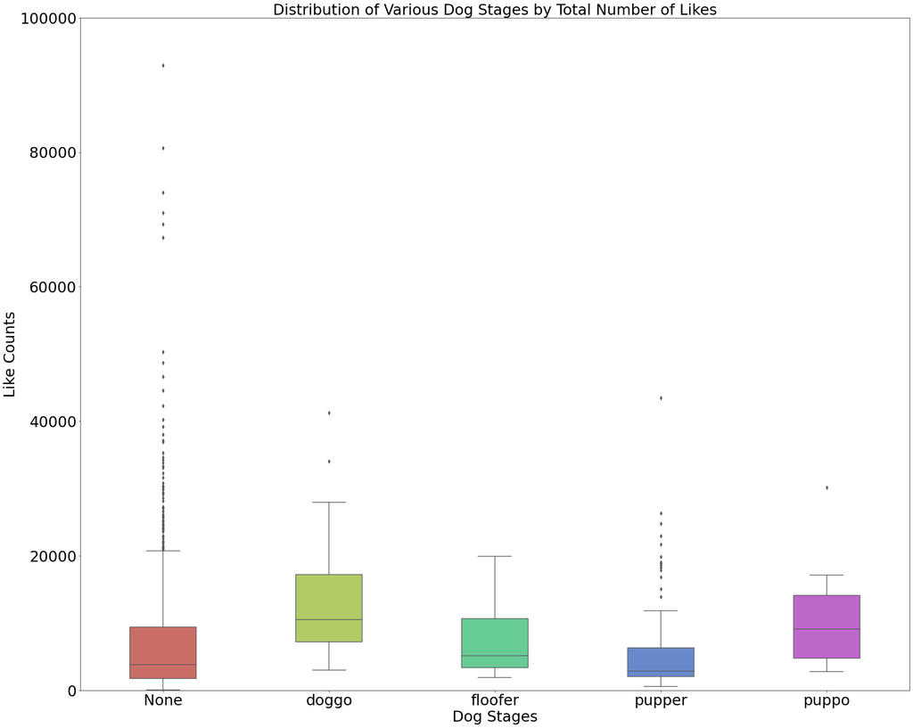

Similar observation was made for number of likes as with number of retweets. The pattern in terms of the mean distribution is as follows: doggo > puppo > floofer > none > pupper.

However, those in the "none" class had many outliers.

## Regression Analysis Showing the Effect of Retweet Counts and Number of Likes on the Confidence of Prediction.

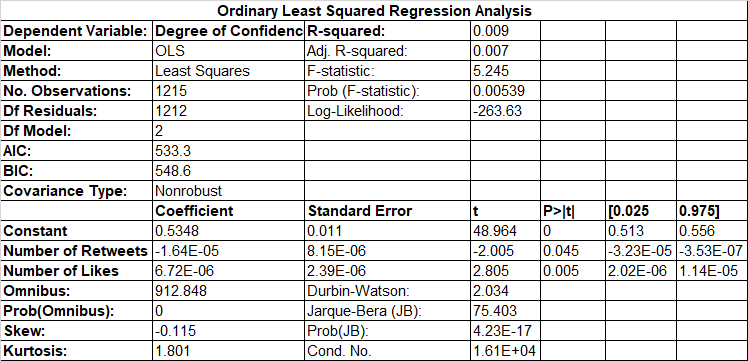

A linear regression (Ordinary Least Square method) was used to explore the effect of retweet counts and number of likes on the confidence of prediction of dog breeds.In explaining the linear regression results, certain outputs are pertinent.

The R-squared value describes the fitness of the model in estimating this relationship. The R-squared is the fraction of the variation in the dependent variable (confidence of prediction) that is accounted for (or predicted by) the independent variables (number of retweets and number of likes). An R-squared value of 0.009 implies that less than 1% of the variation in the dependent variable is explained by the independent variable. The P-values, 0.045 and 0.005 for number of retweets and number of likes respectively show a significant effect of each of the independent variables on the prediction confidence. While the number of retweets had a negative effect (as shown by the value of the co-efficient), meaning an inverse relationship between the number of retweets and the confidence of prediction, the number of likes showed a positive effect (as shown by the coefficeint) meaning a direct relationship between number of likes and prediction confidence. The low value for the R-squared is of great concern as well as the inverse relationship between the number of retweets and the confidence of prediction. This makes the model adopted for this analysis doubtful.

To provide further insight, I used the Generalized Linear Model (GLM) to test this relationship (see table below). The results still revealed an inverse relationship between the number of retweets and the confidence of prediction. Number of Likes still had a positive direct relationship with prediction confidence.

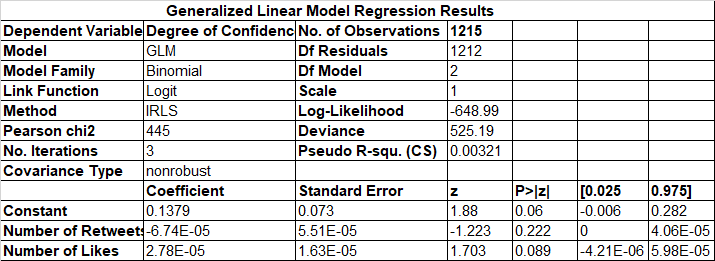